# Fem lecture ch.3

## Motivation

- We study refrence cell at Ch.1 and Ch.2
- In this chapter we study cell’s connect, mesh.

## Mesh Entities

- A mesh is built from topological entities of difference dimensions
- Call entities as Cell’s vertices,edges,cell all.

**Topological entitie pair $(d,i)$**

$d$ is dimention $i$ is index ; unique number at that dimenstion.

## Adjacency

- Adjacency is entitie’s connection.

$$Adj_{d_1,d_2}(n)=(1,2,3)$$

$d_1$ dimention n’s entitie cell has $d_2$ dimention’s entitie number 1,2,3. n’s triangle origined 1,2,3 entities.

## Mesh Geometry

- We know cell’s connect by adjacency.
- In mesh geometry, we know positon of cell.

Convert refrence cell to physical cell by Jacobian.

$$(\zeta,\eta) \rightarrow (x,y)$$

- dolfinx calculate jacobian auto.

## Mesh generate

- This section is how implement mesh.

```python
#| echo: False
#| output: False
#| warning: False

msh_tri = mesh.create_unit_square(
    MPI.COMM_WORLD, 8, 8,
    cell_type=mesh.CellType.triangle      # → 128 cells
)
msh_quad = mesh.create_unit_square(
    MPI.COMM_WORLD, 8, 8,
    cell_type=mesh.CellType.quadrilateral  # → 64 cells
)
# Rectangle [0,2]×[0,0.5] — 16×4 grid → 128 triangle cells
msh_rect = mesh.create_rectangle(
    MPI.COMM_WORLD,
    [np.array([0., 0.]), np.array([2., 0.5])], [16, 4]
)
# Unit cube [0,1]^3 — 4×4×4 → 384 tet cells
msh_3d = mesh.create_unit_cube(MPI.COMM_WORLD, 4, 4, 4)
```

- Mesh view

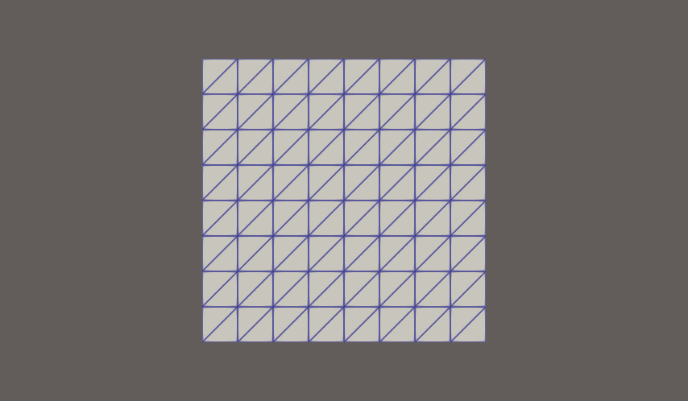

triangle

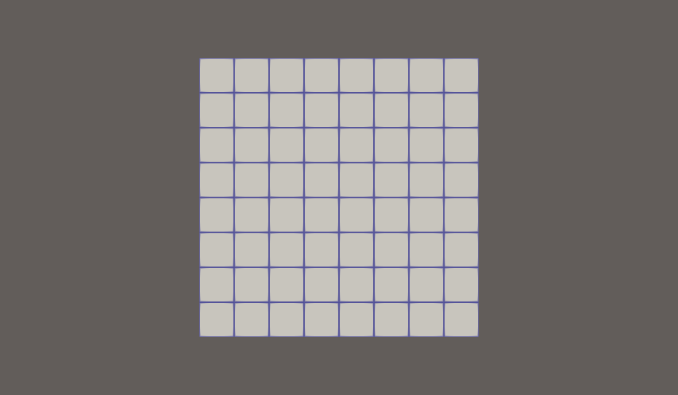

quadlirateral

[figure not shown]

rectangle

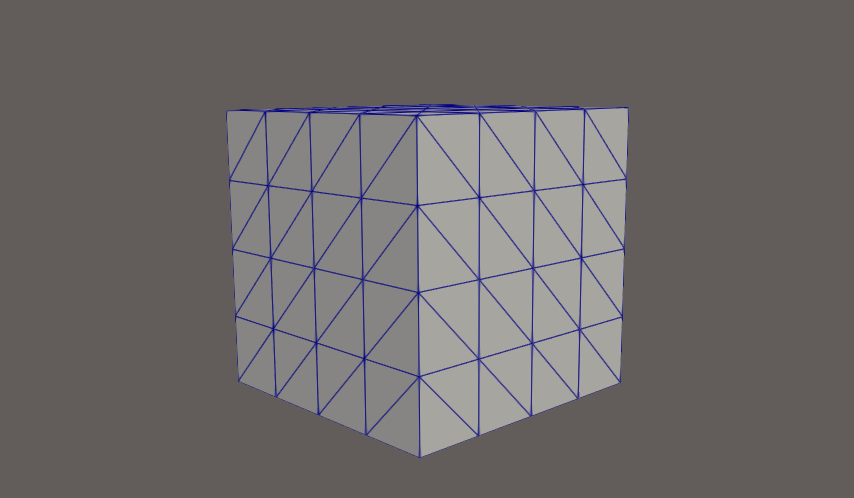

cube

- Mesh diagonal option

```python
#| echo: False
#| output: False
#| warning False
# Default diagonal direction
msh_right = mesh.create_unit_square(
    MPI.COMM_WORLD, 4, 4,
    diagonal=mesh.DiagonalType.right
)
# Left diagonal
msh_left = mesh.create_unit_square(
    MPI.COMM_WORLD, 4, 4,
    diagonal=mesh.DiagonalType.left
)
# Crossed (Union Jack pattern)
msh_crossed = mesh.create_unit_square(
    MPI.COMM_WORLD, 4, 4,
    diagonal=mesh.DiagonalType.crossed
)
```

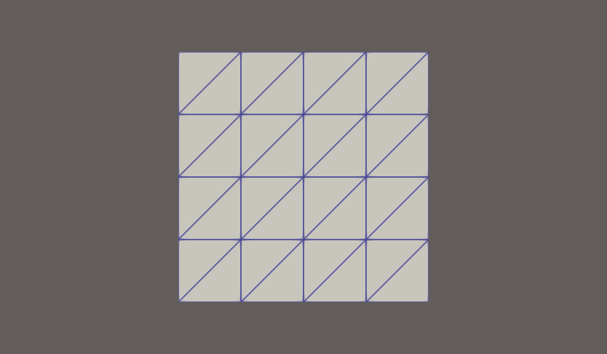

right

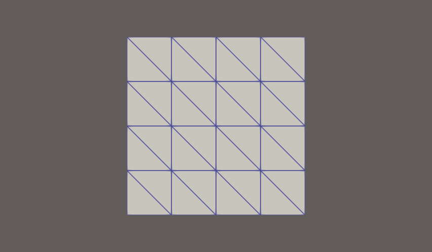

left

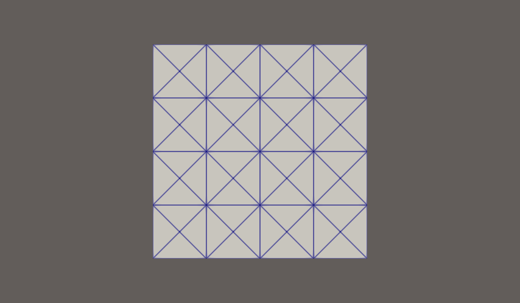

cross

## Use gmsh on complexible mesh.

```python
#| echo: False
#| ouput: False
#| warning: False
import gmsh
gmsh.initialize()
# Create geometry
disk=gmsh.model.occ.addDisk(0, 0, 0, 1, 1)  # unit disk
gmsh.model.occ.synchronize()

gmsh.model.addPhysicalGroup(2,[disk],1)

# Set mesh size
gmsh.model.mesh.setSize(
    gmsh.model.getEntities(0), 0.1
)
# Generate 2D mesh
gmsh.model.mesh.generate(2)
# Import into DOLFINx

meshdata=gmshio.model_to_mesh(gmsh.model,MPI.COMM_WORLD,0,2)
dom=meshdata.mesh

cell_tags=meshdata.cell_tags
facet_tags=meshdata.facet_tags

gmsh.finalize()
```

- domain made by gmshio

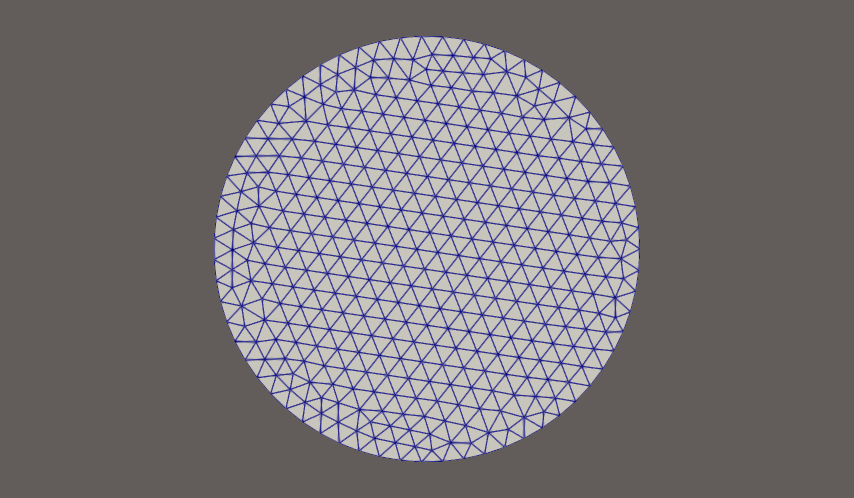

gmsh

- domain made by `.msh`

```python
#| echo: False
#| ouput: False
#| warning: False

meshdata1=gmshio.read_from_msh(
    "/home/ss/untitled.msh",MPI.COMM_WORLD,
    0,3
)

dom1=meshdata1.mesh
cell_tags1=meshdata1.cell_tags
facet_tags1=meshdata1.facet_tags


with XDMFFile(MPI.COMM_WORLD, "dom1.xdmf", "w") as xdmf:
    xdmf.write_mesh(dom1)
```

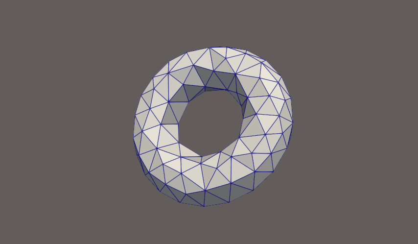

torus

torus

## Mesh inspection

- See Mesh create well.

```python
#| echo: False
#| ouput: false
#| warning: False

import numpy as np
msh = mesh.create_unit_square(MPI.COMM_WORLD, 4, 4)
tdim = msh.topology.dim
# Create all entities and connectivities
for d in range(tdim + 1):
    msh.topology.create_entities(d)
msh.topology.create_connectivity(tdim, 0)
msh.topology.create_connectivity(tdim, tdim - 1)
# Print summary
for d in range(tdim + 1):
    n = msh.topology.index_map(d).size_local
    names = {0: "vertices", 1: "edges", 2: "cells"}
    print(f"  dim {d} ({names[d]}): {n}")
# Print first 3 cells
c2v = msh.topology.connectivity(tdim, 0)
for c in range(min(3, msh.topology.index_map(tdim).size_local)):
    verts = [int(x) for x in c2v.links(c)]
    coords = msh.geometry.x[msh.geometry.dofmap[c], :2]
    print(f"  Cell {c}: verts={verts}, "
          f"coords={coords.tolist()}")

with XDMFFile(MPI.COMM_WORLD, "msh.xdmf", "w") as xdmf:
    xdmf.write_mesh(msh)
```

- Output

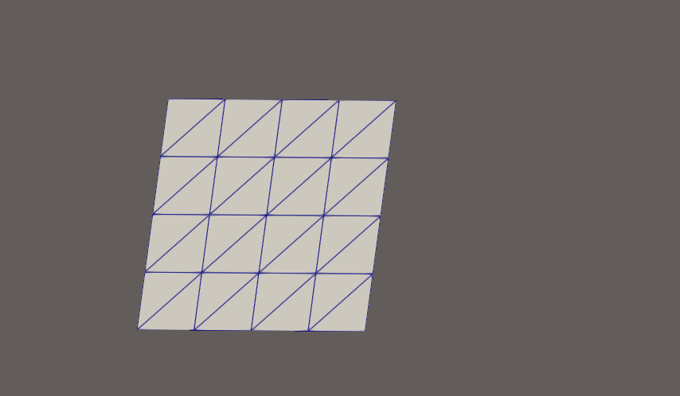

msh

```
  dim 0 (vertices): 25
  dim 1 (edges): 56
  dim 2 (cells): 32
  Cell 0: verts=[0, 1, 2], coords=[[0.75, 0.0], [1.0, 0.0], [1.0, 0.25]]
  Cell 1: verts=[0, 3, 2], coords=[[0.75, 0.0], [0.75, 0.25], [1.0, 0.25]]
  Cell 2: verts=[4, 0, 3], coords=[[0.5, 0.0], [0.75, 0.0], [0.75, 0.25]]
```

## Excercise

## Exercises

**Exercise 1 — Mesh Exploration**

1. Create a $4 \times 4$ unit square mesh with `right` diagonal
2. Print the number of vertices, edges, and cells
3. For each cell, print vertex indices (use `[int(x) for x in ...]`) — note: **not ascending** in DOLFINx; verify $\det J > 0$ instead
4. Compute $|J|$ for each cell and verify they are all equal (uniform mesh)
- Code

```python
square=mesh.create_unit_square(MPI.COMM_WORLD,
                               4,4,
                               diagonal=mesh.DiagonalType.right)

tdim=square.topology.dim

for dim in range(0,tdim+1):
    square.topology.create_entities(dim)

square.topology.create_connectivity(tdim, 0)
square.topology.create_connectivity(tdim, tdim - 1)

for d in range(tdim + 1):
    n = square.topology.index_map(d).size_local
    names = {0: "vertices", 1: "edges", 2: "cells"}
    print(f"  dim {d} ({names[d]}): {n}")

vertic=square.topology.connectivity(tdim,0)

print(vertic)
#print(type(vertic))
'''
<class 'dolfinx.cpp.graph.AdjacencyList_int32'>
Because type is special,
call like `vertic.links(n)`.
'''

coords=square.geometry.x
b=[]
detJ=[]

for i in range(square.topology.index_map(tdim).size_local):

    a=[int(x)  for x in vertic.links(i) ]# i번 셀의 정점인덱스를 저장
    k=(coords[a])
    b.append(k)

    J1=-k[0][0]+k[1][0]
    J2=-k[0][0]+k[2][0]
    J3=-k[0][1]+k[1][1]
    J4=-k[0][1]+k[2][1]

    dJ=J1*J4-J2*J3
    detJ.append(dJ)


#print(b)

#print(vertic.links(0))
#print(coords[vertic.links(0)])
print(detJ)
```

- How calculate Jacobian at first lagrange space
- shape function

$$x(\zeta,\eta)=(1-\zeta-\eta)x_0+\zeta x_1+\eta x_2$$

$$y(\zeta,\eta)=(1-\zeta-\eta)y_0+\zeta x_1+\eta y_2$$

$$J=\begin{pmatrix} -x_0+x_1 & -x_0+x_2 \\
-y_0+y_1 & -y_0+y_2 \end{pmatrix}$$

- Output

[output not shown]

**Exercise 2 — Adjacency**

1. Create a $3 \times 3$ unit square mesh
2. Compute and print $\mathrm{Adj}_{2,0}$, $\mathrm{Adj}_{2,1}$, and $\mathrm{Adj}_{1,0}$ for all entities
3. For edge 0, find which cells contain it (upward adjacency $\mathrm{Adj}_{1,2}$)
4. Verify: each interior edge is shared by exactly 2 cells, each boundary edge by 1
- Solution

```python
mesh11=mesh.create_unit_square(MPI.COMM_WORLD,3,3,
                               )

mesh11.topology.create_connectivity(2,0)
mesh11.topology.create_connectivity(2,1)
mesh11.topology.create_connectivity(1,0)

Adj20=mesh11.topology.connectivity(2,0)
Adj21=mesh11.topology.connectivity(2,1)
Adj10=mesh11.topology.connectivity(1,0)
#Adj12=mesh11.topology.connectivity(1,2)

print(f'$Adj_{{2,0}}${Adj20}')
print(f'$Adj_{{2,1}}${Adj21}')
print(f'$Adj_{{1,0}}${Adj10}')
#print(f'$Adj_{1,2}${Adj12}')


cnt=0

for i in range(mesh11.topology.index_map(1).size_local):

    for j in range(mesh11.topology.index_map(2).size_local):
        x=Adj21.links(j)
        if x[0]==i or x[1]==i or x[2]==i :
            cnt+=1
            print(f'Edge {i} in cell{j}')

        if cnt==3:
            print('broken mesh')
            break
```

- Output

[figure not shown]

exercise2

```
$Adj_{2,0}$<AdjacencyList> with 18 nodes
  0: [0 1 2 ]
  1: [0 3 2 ]
  2: [4 0 3 ]
  3: [3 2 5 ]
  4: [4 6 3 ]
  5: [3 7 5 ]
  6: [8 4 6 ]
  7: [6 3 7 ]
  8: [7 5 9 ]
  9: [8 10 6 ]
  10: [6 11 7 ]
  11: [7 12 9 ]
  12: [10 6 11 ]
  13: [11 7 12 ]
  14: [10 13 11 ]
  15: [11 14 12 ]
  16: [13 11 14 ]
  17: [13 15 14 ]

$Adj_{2,1}$<AdjacencyList> with 18 nodes
  0: [4 1 0 ]
  1: [5 1 2 ]
  2: [2 7 3 ]
  3: [6 8 5 ]
  4: [9 7 11 ]
  5: [13 8 10 ]
  6: [11 16 12 ]
  7: [10 15 9 ]
  8: [14 19 13 ]
  9: [17 16 22 ]
  10: [20 15 18 ]
  11: [23 19 21 ]
  12: [18 24 17 ]
  13: [21 26 20 ]
  14: [27 24 25 ]
  15: [29 26 28 ]
  16: [28 30 27 ]
  17: [32 30 31 ]

$Adj_{1,0}$<AdjacencyList> with 33 nodes
  0: [0 1 ]
  1: [0 2 ]
  2: [0 3 ]
  3: [0 4 ]
  4: [1 2 ]
  5: [2 3 ]
  6: [2 5 ]
  7: [3 4 ]
  8: [3 5 ]
  9: [3 6 ]
  10: [3 7 ]
  11: [4 6 ]
  12: [4 8 ]
  13: [5 7 ]
  14: [5 9 ]
  15: [6 7 ]
  16: [6 8 ]
  17: [6 10 ]
  18: [6 11 ]
  19: [7 9 ]
  20: [7 11 ]
  21: [7 12 ]
  22: [8 10 ]
  23: [9 12 ]
  24: [10 11 ]
  25: [10 13 ]
  26: [11 12 ]
  27: [11 13 ]
  28: [11 14 ]
  29: [12 14 ]
  30: [13 14 ]
  31: [13 15 ]
  32: [14 15 ]

Edge 0 in cell0
Edge 1 in cell0
Edge 1 in cell1
Edge 2 in cell1
Edge 2 in cell2
Edge 3 in cell2
Edge 4 in cell0
Edge 5 in cell1
Edge 5 in cell3
Edge 6 in cell3
Edge 7 in cell2
Edge 7 in cell4
Edge 8 in cell3
Edge 8 in cell5
Edge 9 in cell4
Edge 9 in cell7
Edge 10 in cell5
Edge 10 in cell7
Edge 11 in cell4
Edge 11 in cell6
Edge 12 in cell6
Edge 13 in cell5
Edge 13 in cell8
Edge 14 in cell8
Edge 15 in cell7
Edge 15 in cell10
Edge 16 in cell6
Edge 16 in cell9
Edge 17 in cell9
Edge 17 in cell12
Edge 18 in cell10
Edge 18 in cell12
Edge 19 in cell8
Edge 19 in cell11
Edge 20 in cell10
Edge 20 in cell13
Edge 21 in cell11
Edge 21 in cell13
Edge 22 in cell9
Edge 23 in cell11
Edge 24 in cell12
Edge 24 in cell14
Edge 25 in cell14
Edge 26 in cell13
Edge 26 in cell15
Edge 27 in cell14
Edge 27 in cell16
Edge 28 in cell15
Edge 28 in cell16
Edge 29 in cell15
Edge 30 in cell16
Edge 30 in cell17
Edge 31 in cell17
Edge 32 in cell17
```

**Exercise 3 — Gmsh Integration**

1. Use Gmsh to create an L-shaped domain (unit square minus a quarter)
2. Import into DOLFINx
3. Count mesh entities and verify the mesh covers the expected area
4. Identify and count boundary facets on each segment of the L-shape

## Solution

```python
gmsh.initialize()

a=gmsh.model.occ.addRectangle(0,0,0,1,1)
b=gmsh.model.occ.addRectangle(0.5,0.5,0,0.5,0.5)
c,_=gmsh.model.occ.cut([(2,a)],[(2,b)])

gmsh.model.occ.synchronize()

gmsh.model.addPhysicalGroup(2,[c[0][1]],1,'s')

gmsh.option.setNumber('Mesh.MeshSizeMin',0.49)
gmsh.option.setNumber('Mesh.MeshSizeMax',0.5)

gmsh.model.mesh.generate(2)

meshdata=gmshio.model_to_mesh(gmsh.model,MPI.COMM_WORLD,0,2)
domain=meshdata.mesh

gmsh.finalize()

with XDMFFile(MPI.COMM_WORLD, "Lshape1.xdmf", "w") as xdmf:
    xdmf.write_mesh(domain)



domain.topology.create_connectivity(2,1)
domain.topology.create_connectivity(1,0)


print(f'vertex{domain.topology.index_map(0).size_local}')
print(f'edgy{domain.topology.index_map(1).size_local}')
print(f'cell {domain.topology.index_map(2).size_local}')


Adj21=domain.topology.connectivity(2,1)

y=0
z=0

for i in range(domain.topology.index_map(1).size_local):
    for j in range(domain.topology.index_map(2).size_local):
        x=Adj21.links(j)
        if x[0]==i or x[1]==i or x[2]==i:
            y+=1
    if y==1: z+=1
    y=0

print(f'boundary facet {z}')
```

- Output

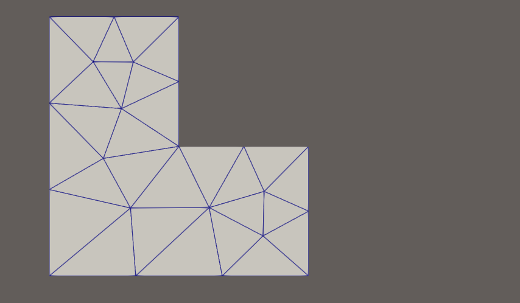

Lshape

- Output

```
vertex22
edgy49
cell 28
boundary facet 14
```

We know domain is flat by **Euler’s polyhedron formula**.

We can’t know domain created well directly without visualization.

## Fix the number of divisions.

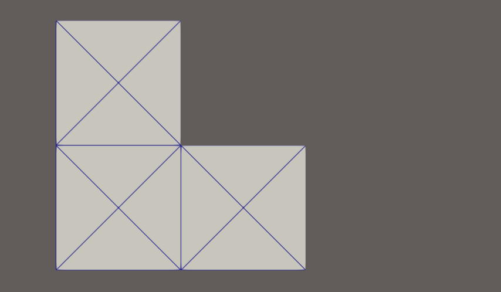

Lshape

```python
gmsh.initialize()

a=gmsh.model.occ.addRectangle(0,0,0,1,1)
b=gmsh.model.occ.addRectangle(0.5,0.5,0,0.5,0.5)
c,_=gmsh.model.occ.cut([(2,a)],[(2,b)])

gmsh.model.occ.synchronize()

gmsh.model.addPhysicalGroup(2,[c[0][1]],1,'s')

tag=gmsh.model.getBoundary(c,oriented=False)

for dim,tags in tag:
    L=gmsh.model.occ.getMass(dim,tags)
    if round(L)==1:
        gmsh.model.mesh.setTransfiniteCurve(tags,3)
    else:
        gmsh.model.mesh.setTransfiniteCurve(tags,2)



gmsh.model.mesh.generate(2)

meshdata=gmshio.model_to_mesh(gmsh.model,MPI.COMM_WORLD,0,2)
domain=meshdata.mesh

gmsh.finalize()

with XDMFFile(MPI.COMM_WORLD, "Lshape4.xdmf", "w") as xdmf:
    xdmf.write_mesh(domain)



domain.topology.create_connectivity(2,1)
domain.topology.create_connectivity(1,0)


print(f'vertex{domain.topology.index_map(0).size_local}')
print(f'edgy{domain.topology.index_map(1).size_local}')
print(f'cell {domain.topology.index_map(2).size_local}')


Adj21=domain.topology.connectivity(2,1)

y=0
z=0

for i in range(domain.topology.index_map(1).size_local):
    for j in range(domain.topology.index_map(2).size_local):
        x=Adj21.links(j)
        if x[0]==i or x[1]==i or x[2]==i:
            y+=1
    if y==1: z+=1
    y=0

print(f'boundary facet {z}')
```

- Output

```
vertex11
edgy22
cell 12
boundary facet 8
```